# WUI & Suppression

## Suppression Functions

### add_resource!

Add a suppression resource to the state.

```julia
add_resource!(state::SuppressionState, resource::SuppressionResource)
```

### construct_containment_line!

Build a containment line from start to target.

```julia
construct_containment_line!(state::SuppressionState, resource::SuppressionResource,
    start_ix, start_iy, target_ix, target_iy, dt::T, cellsize::T, t::T
) -> Tuple{Vector{Tuple{Int,Int}}, T}
```

Returns `(cells_built, length_built)`.

```julia
# Build a containment line
cells, length_ft = construct_containment_line!(
    supp_state,
    supp_state.resources[3],  # Dozer (fast)
    30, 30,                   # Start
    30, 50,                   # Target
    10.0,                     # Time available (min)
    30.0,                     # Cell size (ft)
    0.0                       # Current time
)

println("Built $(length(cells)) cells ($(round(length_ft, digits=0)) ft)")
```

```
Built 0 cells (0.0 ft)
```

### assign_resource!

Assign a resource to build line along specified targets.

```julia
assign_resource!(state::SuppressionState, resource_id::Int, targets::Vector{Tuple{Int,Int}})
```

### apply_containment!

Apply containment line effects to reduce fire spread.

```julia
apply_containment!(fire_state::FireState, suppression_state::SuppressionState)
```

### plan_indirect_attack

Plan an indirect attack line ahead of the fire.

```julia
plan_indirect_attack(fire_state::FireState, weather, buffer_cells::Int) -> Vector{Tuple{Int,Int}}
```

### plan_direct_attack

Plan a direct attack on the fire perimeter.

```julia
plan_direct_attack(fire_state::FireState) -> Vector{Tuple{Int,Int}}
```

### simulate_with_suppression!

Run simulation with suppression activities.

```julia
simulate_with_suppression!(
    fire_state::FireState,
    supp_state::SuppressionState,
    fuel_ids, fuel_table, weather,
    slope, aspect, t_start, t_stop;
    kwargs...
)
```

### get_suppression_statistics

Get summary statistics from suppression operations.

```julia
get_suppression_statistics(state::SuppressionState) -> NamedTuple
```

```julia
stats = get_suppression_statistics(supp_state)

println("Suppression Statistics:")
println("  Total resources: $(stats.total_resources)")
println("  Available: $(stats.available)")
println("  Deployed: $(stats.deployed)")
println("  Contained cells: $(stats.contained_cells)")
println("  Total line: $(round(stats.total_line_feet, digits=0)) ft")
```

```
Suppression Statistics:
  Total resources: 3
  Available: 3
  Deployed: 0
  Contained cells: 0
  Total line: 0.0 ft
```

## Example: Fire with Suppression

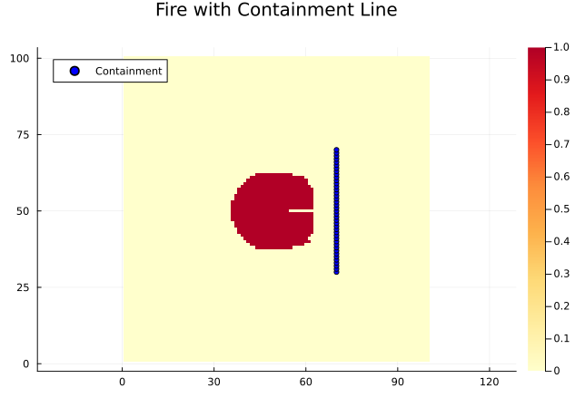

```julia
ncols, nrows = 100, 100
cellsize = 30.0

fire_state = FireState{Float64}(ncols, nrows, cellsize)
supp_state = SuppressionState{Float64}(ncols, nrows)
fuel_table = create_standard_fuel_table(Float64)
fuel_ids = fill(1, ncols, nrows)
slope = zeros(Float64, ncols, nrows)
aspect = zeros(Float64, ncols, nrows)

weather = ConstantWeather{Float64}(
    wind_speed_mph = 10.0,
    wind_direction = 270.0,
    M1 = 0.06, M10 = 0.08, M100 = 0.10,
    MLH = 0.60, MLW = 0.90
)

# Add a dozer
dozer = SuppressionResource{Float64}(1, :dozer; location_x = 70.0, location_y = 50.0)
add_resource!(supp_state, dozer)

# Pre-build containment line
for y in 30:70
    supp_state.contained_cells[70, y] = true
    supp_state.containment_effectiveness[70, y] = 0.1  # 90% reduction
end

# Ignite and run
ignite!(fire_state, 40, 50, 0.0)

simulate_with_suppression!(
    fire_state, supp_state,
    fuel_ids, fuel_table, weather,
    slope, aspect, 0.0, 45.0
)

# Visualize
p = heatmap(fire_state.burned',
    title = "Fire with Containment Line",
    color = :YlOrRd,
    aspect_ratio = 1
)

# Overlay containment line
contained_x = [ix for ix in 1:ncols for iy in 1:nrows if supp_state.contained_cells[ix, iy]]
contained_y = [iy for ix in 1:ncols for iy in 1:nrows if supp_state.contained_cells[ix, iy]]
scatter!(p, contained_x, contained_y, color = :blue, markersize = 3, label = "Containment")

p
```

## Comparing Suppressed vs. Unsuppressed

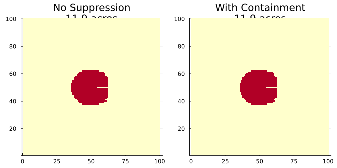

```julia
# Without suppression
state_no_supp = FireState{Float64}(ncols, nrows, cellsize)
ignite!(state_no_supp, 40, 50, 0.0)
simulate_uniform!(state_no_supp, 1, fuel_table, weather, 0.0, 0.0, 0.0, 45.0)

# With suppression (already run above)

p1 = heatmap(state_no_supp.burned',
    title = "No Suppression\n$(round(get_burned_area_acres(state_no_supp), digits=1)) acres",
    color = :YlOrRd, aspect_ratio = 1, colorbar = false)

p2 = heatmap(fire_state.burned',
    title = "With Containment\n$(round(get_burned_area_acres(fire_state), digits=1)) acres",
    color = :YlOrRd, aspect_ratio = 1, colorbar = false)

plot(p1, p2, layout = (1, 2), size = (700, 350))
```

## WUI Simulation Example

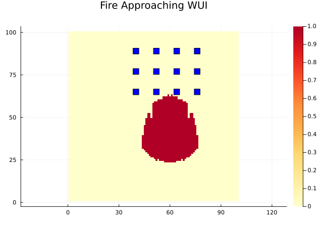

```julia
ncols, nrows = 100, 100
cellsize = 30.0

# Create fire state and landscape
state = FireState{Float64}(ncols, nrows, cellsize)
fuel_ids = fill(1, ncols, nrows)
slope = zeros(Float64, ncols, nrows)
aspect = zeros(Float64, ncols, nrows)

# Create buildings in the northern part
buildings = WUIBuilding{Float64}[]
id = 0
for ix in 40:12:80
    for iy in 65:12:90
        id += 1
        ctype = rand([:wood, :wood, :masonry])
        push!(buildings, WUIBuilding{Float64}(id, ix, iy; construction_type = ctype))
    end
end

wui_grid = WUIGrid{Float64}(buildings, ncols, nrows)

# Wind from south (pushing fire toward buildings)
weather = ConstantWeather{Float64}(
    wind_speed_mph = 12.0,
    wind_direction = 180.0,
    M1 = 0.05, M10 = 0.07, M100 = 0.09,
    MLH = 0.50, MLW = 0.80
)

# Ignite in southern portion
ignite!(state, 60, 30, 0.0)

# Run simulation
simulate_uniform!(state, 1, fuel_table, weather, 0.0, 0.0, 0.0, 60.0)

# Update WUI state
rng = MersenneTwister(42)
t = 0.0
while t < 60.0
    ignitions = update_wui_state!(wui_grid, state, weather, t, 1.0, rng)
    for ig in ignitions
        println("Building $(ig.building_id) ignited at t=$(round(ig.ignition_time, digits=1))")
    end
    t += 1.0
end

# Visualize
p = heatmap(state.burned',
    title = "Fire Approaching WUI",
    color = :YlOrRd,
    aspect_ratio = 1
)

# Add buildings
building_x = [b.ix for b in buildings]
building_y = [b.iy for b in buildings]
colors = [wui_grid.ignited[i] ? :red : :blue for i in 1:length(buildings)]

scatter!(p, building_x, building_y,
    color = colors,
    markersize = 6,
    markershape = :square,
    label = false
)

p
```

```julia
# WUI Statistics
stats = get_wui_statistics(wui_grid)

println("WUI Results:")
println("  Total buildings: $(stats.total_buildings)")
println("  Ignited: $(stats.ignited_buildings)")
println("  Ignition rate: $(round(stats.ignition_fraction * 100, digits=1))%")
if stats.ignited_buildings > 0
    println("  First ignition: $(round(stats.first_ignition_time, digits=1)) min")
    println("  Last ignition: $(round(stats.last_ignition_time, digits=1)) min")
end
```

```
WUI Results:
  Total buildings: 12
  Ignited: 0
  Ignition rate: 0.0%
```